# Deciphering the role of Histone Modifications in Memory and Exhausted CD8 T Cells - Part 3

### 9.4.2) Memory T-cells

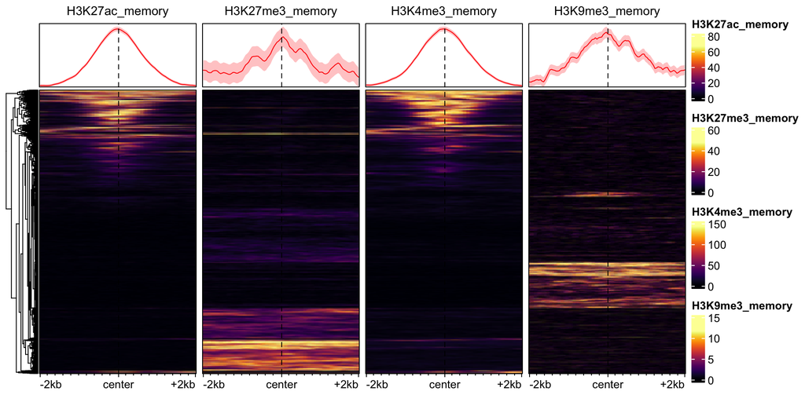

Figure 8. Enriched heatmap of histone modifications at genomic regions in memory T-cells. Heatmaps display the enrichment of four histone modifications—H3K27ac, H3K27me3, H3K4me3, and H3K9me3—across genomic regions centred at defined loci (centre, dashed line), spanning ±2 kb. Each row represents an individual genomic region, clustered by signal intensity. The colour scale indicates the normalised ChIP-seq signal for each modification, as shown by the colour bars on the right. Above each heatmap, the average signal profile (red line) with shaded confidence intervals summarises enrichment patterns across all regions

```r
plotEnrichedHeatmaps(sm_m1,  multiScale = T, cluster_rows = T, show_row_dend = T)
```

In memory T-cells, H3K27ac and H3K4me3 remain strongly enriched at the centre of the regions, marking active promoters and enhancers. H3K27me3 shows a more complex pattern than in naïve T-cells, with clear central enrichment at some sites and additional peaks on either side, pointing to changes in how repressive chromatin is organised. H3K9me3 is enriched both at the centre and flanking regions in certain loci, suggesting that heterochromatin forms at specific genomic sites during memory T-cell differentiation. Clustering reveals distinct chromatin states, and in some regions, active and repressive marks appear together — particularly noticeable in the H3K27me3 pattern.

### 9.4.3) Exhausted T-cells

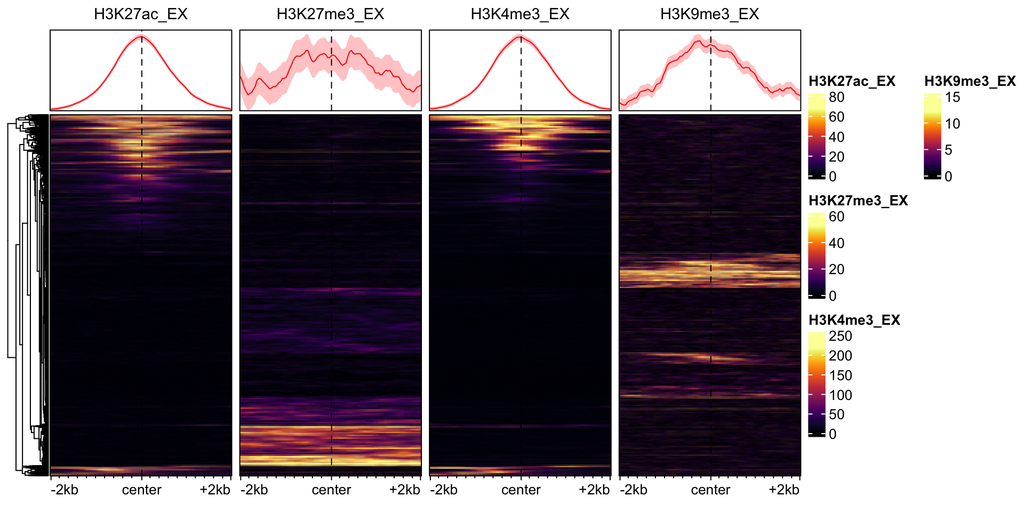

Figure 9. Heatmaps and average profiles of histone modifications at genomic regions in exhausted T-cells. Heatmaps display the enrichment of four histone modifications—H3K27ac, H3K27me3, H3K4me3, and H3K9me3—across genomic regions centred at defined loci (centre, dashed line), spanning ±2 kb. Each row represents an individual genomic region, clustered by signal intensity as shown in the dendrogram on the left. The colour scales indicate the normalised ChIP-seq signal for each modification. Above each heatmap, the average signal profile (red line) with shaded confidence intervals summarises enrichment patterns across all regions.

```r
plotEnrichedHeatmaps(sm_e1,  multiScale = T, cluster_rows = T, show_row_dend = T)
```

In exhausted T-cells, H3K27ac and H3K4me3 remain enriched at the centre of regions, suggesting that active regulatory elements are still marked, although the strength of these signals may differ from other T-cell states. H3K27me3 shows a distinct pattern, with moderate central enrichment and additional flanking signal, hinting at a more complex repressive chromatin landscape. H3K9me3 stands out with a striking redistribution, showing strong enrichment in specific clusters of regions — consistent with widespread heterochromatin formation and gene silencing in the exhausted state. Clustering highlights clear chromatin signatures, with regions separating based on their histone mark profiles, most notably through the patterns of H3K9me3.

## 9.5) Clustering

### 9.5.1) Finding the best kmeans for clustering of the samples

```r
cl_n <- clusterSignalMatrices(sm_n1, k=2:7)
cluster1 <- ggplot(cl_n$varExplained, aes(k, varExplained)) + geom_line() + labs(x = "Number of Clusters (k)", y = "Variance Explained") + ggtitle("A) Cluster Signal Matrix Naive T-Cells")  + theme_minimal()

cl_m <- clusterSignalMatrices(sm_m1, k=2:7)
cluster2 <- ggplot(cl_m$varExplained, aes(k, varExplained)) + geom_line() + labs(x = "Number of Clusters (k)", y = "Variance Explained") + ggtitle("B) Cluster Signal Matrix Memory T-Cells") + theme_minimal()

cl_e <- clusterSignalMatrices(sm_e1, k=2:7)
cluster3 <- ggplot(cl_e$varExplained, aes(k, varExplained)) + geom_line() + labs(x = "Number of Clusters (k)", y = "Variance Explained")+ ggtitle("C) Cluster Signal Matrix Exhausted T-Cells") + theme_minimal()
```

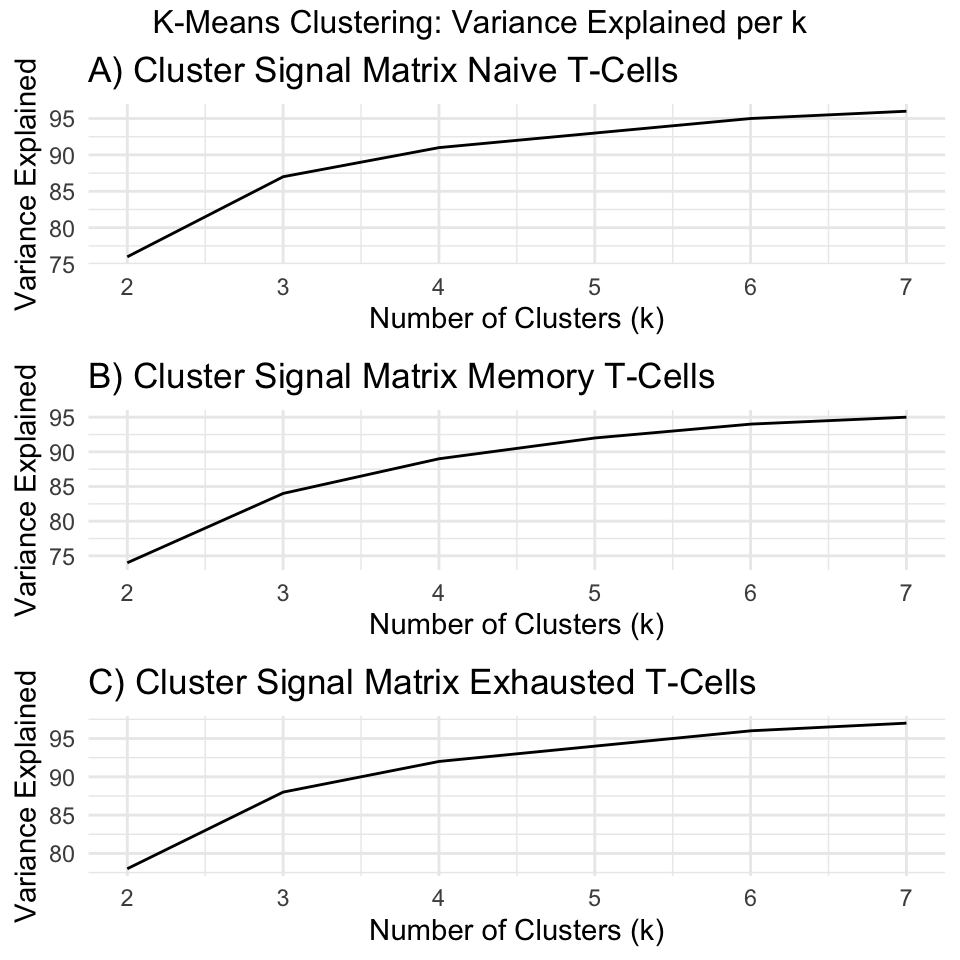

Figure 10. K-means clustering: Variance Explained by k for all three T-cell types: A) naive T-cells, B) memory T-cells, C) exhausted T-cells. x-axis visualises the numbers of clusters producced ranging from 2-7 clusters, y-axis shows the corresponding variance that is explained by these clusters.

```r
grid.arrange(cluster1, cluster2, cluster3,
             ncol = 1,
             top = "K-Means Clustering: Variance Explained per k")
```

In all 3 cell types we see a similar pattern of increase of the variance explained by increasing the clusters. For all three groups the same amount of clusters (k= 6) was chosen for further analysis.

### 9.5.2) Setting the clusters

```r
set.seed(123)  # to ensure that it gives the same results everytime
cl_k_n <- clusterSignalMatrices(sm_n1, k=6)
```

```
##   ~95% of the variance explained by clusters
```

```r
cl_k_m <- clusterSignalMatrices(sm_m1, k=6)
```

```
##   ~94% of the variance explained by clusters
```

```r
cl_k_e <- clusterSignalMatrices(sm_e1, k=6)
```

```
##   ~96% of the variance explained by clusters
```

using k = 6 we have an average 95% of the variance explained.